# 04월23일 회귀모형 출석수업 과제물

## 1번.연습문제 6장 4번 (p. 187) 교회 자료를 이용하여 교재 1.7 분석사례와 같이 분석하고, 설명하시오

(단, 둘레를 독립변수로, 면적의 제곱근을 반응변수로 하기 바람)

```r
# 데이터 로드
churches = read.csv("./data/p187.csv", header = T)
head(churches, 3)
```

```
##   no size area
## 1  1  348 3883
## 2  2  369 4392
## 3  3  143  914
```

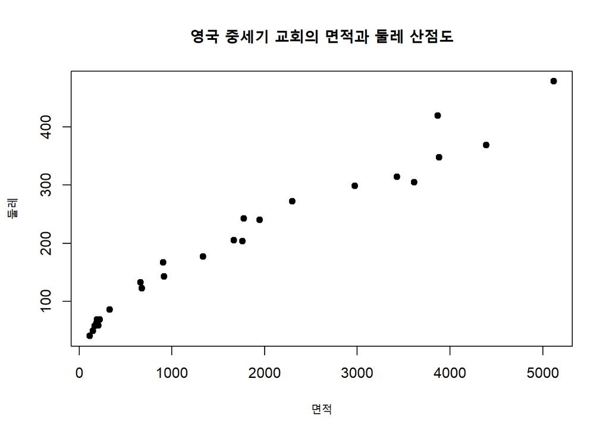

```r
# 오브젝트의 변수를 바로 사용하기 위해 오브젝트 등록
attach(churches)
# 산점도를 그린다.
plot(area, size, pch=19, main="영국 중세기 교회의 면적과 둘레 산점도", xlab="면적", ylab="둘레")
```

```r
# 회귀모형 적합
churches.lm = lm(area~size, data = churches)
summary(churches.lm)
```

```
##
## Call:
## lm(formula = area ~ size, data = churches)
##
## Residuals:
##     Min      1Q  Median      3Q     Max
## -524.19 -139.99   15.64  165.37  606.19
##
## Coefficients:
##              Estimate Std. Error t value Pr(>|t|)
## (Intercept) -674.5399   115.4252  -5.844  5.9e-06 ***
## size          12.0877     0.4947  24.434  < 2e-16 ***
## ---
## Signif. codes:  0 '***' 0.001 '**' 0.01 '*' 0.05 '.' 0.1 ' ' 1
##
## Residual standard error: 307.8 on 23 degrees of freedom
## Multiple R-squared:  0.9629, Adjusted R-squared:  0.9613
## F-statistic:   597 on 1 and 23 DF,  p-value: < 2.2e-16
```

회귀적합 결과에서 회귀계수의 추정값은 절편 $b_0 = -674.5399$이고 기울기 $b_1=12.0877$의 단순회귀방정식은 $\hat{area}=-674.5399 + 12.0877 \times size$ 가 된다. 기울기 $t-값=24.434$이고 $p-값=2\times10^{-16}$이 매우 작으므로 $H_0:\beta_1=0$이라는 귀무가서을 기각한다.  
결정계수 $R^2=0.9629$로서 총변동 중에서 $96.29$%가 회귀방정식으로 설명되는 회귀변동이 차지하고 있다는 것을 나타낸다. $F-값=597$이고, 이에 대한 $P-값=2.2\times10^{-16}$으로서 적합된 회귀직선이 유의하다는 것을 알 수 있다.

```r
# 분산분석표 구하기
anova(churches.lm)
```

```
## Analysis of Variance Table
##
## Response: area
##           Df   Sum Sq  Mean Sq F value    Pr(>F)
## size       1 56578697 56578697  597.04 < 2.2e-16 ***
## Residuals 23  2179607    94766
## ---
## Signif. codes:  0 '***' 0.001 '**' 0.01 '*' 0.05 '.' 0.1 ' ' 1
```

분산분석표에서 보면 검정통계량 $F_0=597.04$이고 이에 대한 $p-값=2.2\times10^{-16}$이 매우 작으므로 적합된 회귀선이 유의하다는 것을 알 수 있다.

```r
# 잔차 및 추정값 보기
# 회귀모형 적합 결과(churches.lm)의 변수 확인
names(churches.lm)
```

```
##  [1] "coefficients"  "residuals"     "effects"       "rank"
##  [5] "fitted.values" "assign"        "qr"            "df.residual"
##  [9] "xlevels"       "call"          "terms"         "model"
```

```r
# churches와 잔차와 추정값을 합쳐서 보기
cbind(churches, churches.lm$resid, churches.lm$fitted)
```

```
##    no size area churches.lm$resid churches.lm$fitted
## 1   1  348 3883         351.03544         3531.96456
## 2   2  369 4392         606.19466         3785.80534
## 3   3  143  914        -139.99500         1053.99500
## 4   4  205 1666        -137.42969         1803.42969
## 5   5  305 3616         603.80467         3012.19533
## 6   6  419 3866        -524.18816         4390.18816
## 7   7  243 1774        -488.76064         2262.76064
## 8   8  240 1946        -280.49767         2226.49767
## 9   9  272 2300        -313.30267         2613.30267
## 10 10  299 2975          35.33061         2939.66939
## 11 11  478 5119          15.64011         5103.35989
## 12 12  133  660        -273.11844          933.11844
## 13 13  167  904        -440.09875         1344.09875
## 14 14  314 3427         306.01576         3120.98424
## 15 15  204 1761         -30.34204         1791.34204
## 16 16  177 1337        -127.97532         1464.97532
## 17 17   59  204         165.36814           38.63186
## 18 18   69  222          62.49157          159.50843
## 19 19   50  146         216.15704          -70.15704
## 20 20   69  192          32.49157          159.50843
## 21 21   63  186          99.01751           86.98249
## 22 22   58  169         142.45579           26.54421
## 23 23   86  331         -33.99859          364.99859
## 24 24   41  113         291.94595         -178.94595
## 25 25  123  674        -138.24187          812.24187
```

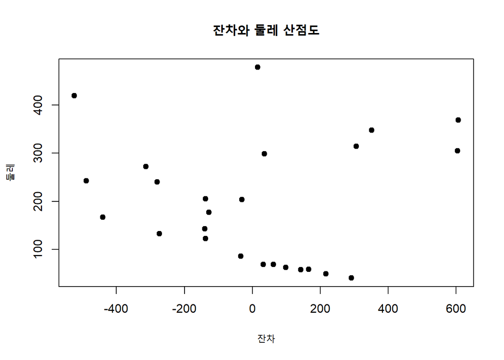

```r
# 잔차를 독립변수 size에 대해 산점도를 그려본다.
plot(churches.lm$resid, size, pch=19, main="잔차와 둘레 산점도", xlab="잔차", ylab="둘레")
# 잔차가 0인 라인 타입 2번 선을 그린다.
abline(h=0,lty=2)
```

잔차는 0을 중심으로 일정한 범위 내에 있으므로 회귀에 대한 기본 가정을 만족한다고 할 수 있으나, X가 증가함에 따라 곡선 관계를 보여주고 있다. 따라서 2차곡선회귀식 $\hat{Y}=b_0+b_1X+b_2X^2$을 구해보는 것도 의미가 있으리라고 생각된다.

[figure not shown]

```r
# 추정값의 신뢰대 그리기
churches.frame = data.frame(size=range(churches$size))
pc = predict(churches.lm, int="c", newdata=churches.frame)
pp = predict(churches.lm, int="p", newdata=churches.frame)
plot(churches$size, churches$area, ylim = range(churches$area, pc), main="영국 중세기 교회의 면적과 둘레 산점도", xlab="면적", ylab="둘레")
matlines(churches.frame$size, pc, lty=c(1,2,2), col="BLUE")
matlines(churches.frame$size, pp, lty=c(1,3,3), col="RED")
```